# Sum of square errors and model training

Training a model is about arranging the model to have the best prediction performance. For a straight-line model, “arranging” means choosing a slope and vertical position (intercept) for the line. The straight line model itself is a function that takes the explanatory variable as the input and produces a value corresponding to the response variable. In other words, the model is a formula

$$\mbox{model output} = m \times \mbox{input} + b$$

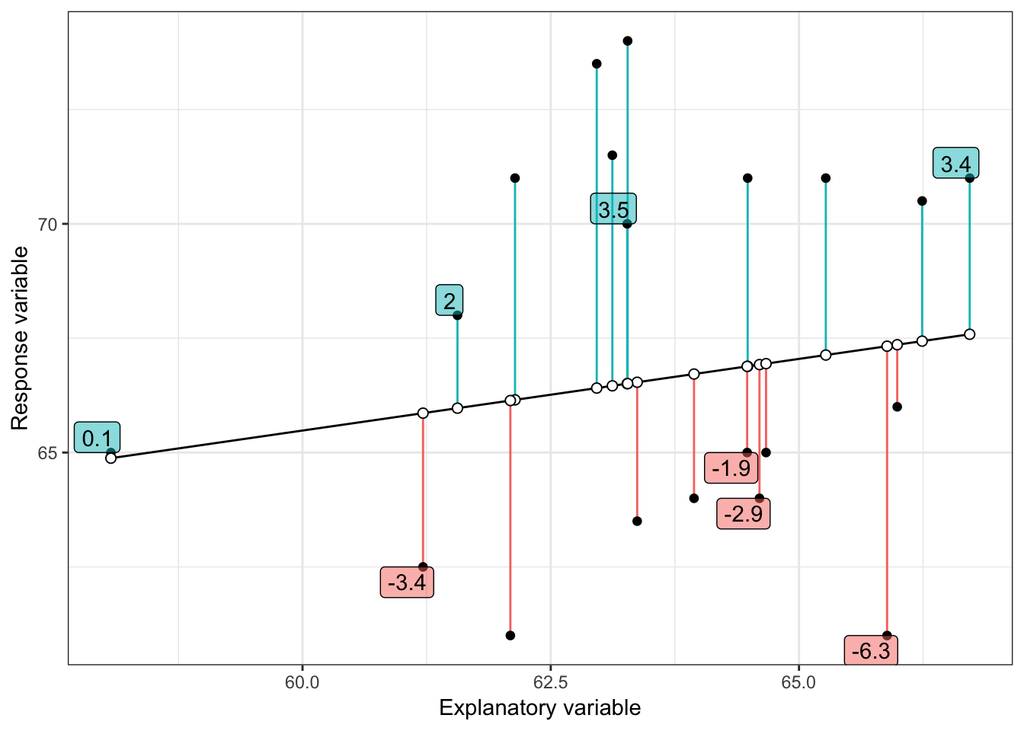

The term “sum of square errors” describes exactly the process of calculation. The result is a *single number* describing how close the proposed model line is to the data. The errors are squared so that the negative errors don’t cancel out the positive ones. (There’s also a subtle link between squaring and the gaussian probability distribution.)

## Using the App

Choose quantitative response and explanatory variables and the sample size in the same way as in the other Little Apps. The main graphic shows the sample as a point plot. It also displays five proposed straight-line models (in five different colors) for describing the relationship between the response and explanatory variables.

For each of the proposed models individually, the sum of square errors is calculated. The result is shown in the *Statistics* tab, which gives the slope, intercept, and sum of square errors for the five lines identified by color in the main plot.

Note that line A will always have the smallest SSE. Line A (red) is the best-fitting straight-line model, that is the straight line having the smallest SSE of all the infinite possibilities for lines of different slopes and intercepts.

The other four lines shown in the main graphic are specified by the two sliders in the *Straight-line controls*. Those sliders let you specify two slopes and two vertical positions. The four lines B, C, D, and E correspond to the four combinations to be made out of two slopes and two vertical positions. Moving any of the sliders changes the position of the corresponding lines in the graphic. In addition to changing the graphic, the SSE shown in the *Statistics* tab will be updated.